# Caring about Code

06/05/2020

## This is not a geek-only seminar

## Why write code ?

## The Selfish Reason

**Research == iterative process**

[figure not shown]

## The Pragmatic Reason

### Sometimes there is no other way…

- Data is too big
- There is no GUI

## The Holy Reason

Research should be

**reproducible**.

## Research compendium

- text
- data
- metadata
- **code**
- *computation environment*

## Code == Blue Print

- From raw data to results
- Anyone can reproduce your analysis
- cf data management plan

## Why write good code ?

## Who is the code for ?

Machine: code == blue print

People:

code

==

Communication medium

## How to write good code

```r
if(code == communication_medium){
    as.text(code)
}
```

## How to write good code

```r
if(code == communication_medium){
    as.text(code)
}
```

1. Enough vocabulary
2. Clear syntax
3. Clear structure

## 1. Enough vocabulary

What to learn ?

## How everybody learns

[figure not shown]

[figure not shown]

Right amount of knowledge

## The basics

[figure not shown]

https://swirlstats.com/

## To get stuff done

## The tidyverse

- Goal-driven
- Easy to use
- Well-maintained

[figure not shown]

https://r4ds.had.co.nz/

[figure not shown]

## To be better

Learn a bit about R data structures

```r
c(factor("a"), factor("b"))
```

```
## [1] 1 1
```

For that: [Advanced R](https://adv-r.hadley.nz/) Chapters 3 and 9

## 2. Clear syntax

## Let it breathe

whenyouarewritinganarticleoremailyoumakesureyouareunder standablebyyourreader

```r
iris_long<-pivot_longer(data=iris,cols=-Species,names_to="Variable",
                                                values_to="Value")
```

## Let it breathe

whenyouarewritinganarticleoremailyoumakesureyourreadercanunderstandyou

```r
iris_long<-pivot_longer(data=iris,cols=-Species,names_to="Variable",
                                                values_to="Value")
```

When you are writing an article or an email,

you make sure your reader can understand you.

```r
iris_long <- pivot_longer(data = iris,
                          cols = -Species,
                          names_to = "Variable",
                          values_to = "Value")
```

```r
head(iris, 2)
```

```
##   Sepal.Length Sepal.Width Petal.Length Petal.Width Species
## 1          5.1         3.5          1.4         0.2  setosa
## 2          4.9         3.0          1.4         0.2  setosa
```

```r
iris_long <- pivot_longer(data = iris,
                          cols = -Species,
                          names_to = "Variable",
                          values_to = "Value")
head(iris_long, 2)
```

```
## # A tibble: 2 x 3
##   Species Variable     Value
##   <fct>   <chr>        <dbl>
## 1 setosa  Sepal.Length   5.1
## 2 setosa  Sepal.Width    3.5
```

## Be explicit

Don’t assume too much knowledge from your reader…

```r
iris_long <- pivot_longer(iris, -Species, "Variable", "Value")
```

```r
iris_long <- pivot_longer(data = iris,
                          cols = -Species,
                          names_to = "Variable",
                          values_to = "Value")
```

## Be explicit

or that their mind is as wicked as yours:

```r
# BAD
a2 <- f(a1, arg1 = b, arg2 = c)
```

```r
# GOOD
plot_farm <- draw_plot_farm(data = data_farm,
                            fields = field_id,
                            organic_input = manure_fert)
```

## Be explicit

Don’t assume too much knowledge from your reader:

- Include argument names to your functions
- Name things explicitly
- Avoid using `T` and `F`

## Be consistent

Don’t write **code** like a child discovering *font* formatting in **MS office**…

```
Data.village
DATAFARM
cleverFunction
smart_function
```

Instead…

## Be consistent

Don’t write **code** like a child discovering *font* formatting in **MS office**…

```
Data.village
DATAFARM
cleverFunction
smart_function
```

Instead…

```
data_village
data_farm
clever_function
smart_function
```

## Be consistent

Special tips:

- Stick to one assignment operator (`<-` or `=`)
- Avoid using `.` as separator

## DRY: Don’t Repeat Yourself

```r
# Chocolate cupcakes
melted_butter <- melt(butter)
dough <- mix(melted_butter, eggs, flour, sugar)
flavoured_dough <- dough + chocolate
cupcakes <- cook(flavoured_dough)

# Vanilla cupcakes
melted_butter <- melt(butter)
dough <- mix(melted_butter, eggs, flour, sugar)
flavoured_dough <- dough + vanilla
cupcakes <- cook(flavoured_dough)

# Blueberry cupcakes
melted_butter <- melt(butter)
dough <- mix(melted_butter, eggs, flour, sugar)
flavoured_dough <- dough + blueberries
cupcakes <- cook(flavoured_dough)
```

## DRY: Don’t Repeat Yourself

```r
bake_cupcakes <- function(special_ingredient){
    melted_butter <- melt(butter)
    dough <- mix(melted_butter, eggs, flour, sugar)
    flavoured_dough <- dough + special_ingredient
    cupcakes <- cook(flavoured_dough)
}
```

```r
special_ingredients <- c("chocolate", "vanilla", "blueberries")

map(special_ingredients, bake_cupcakes)
```

## The Torah Syndrome

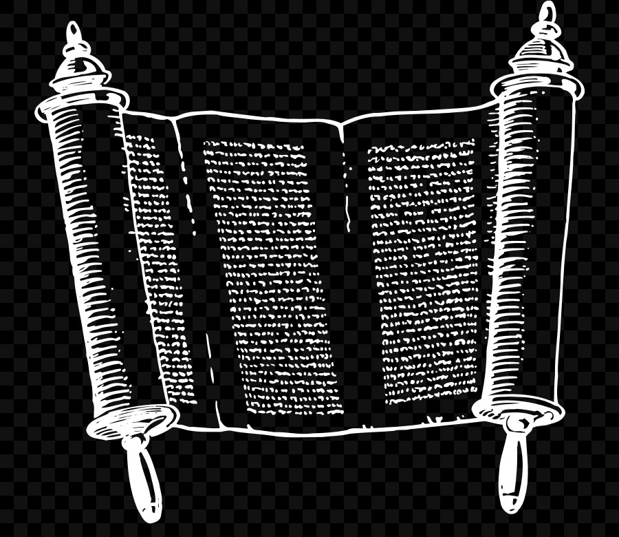

```r
filter(iris, Sepal.Length > 4, Sepal.Width > 3, Petal.Length < 2, Petal.Width > 0.4, Species == "setosa")
```

## The Torah Syndrome

```r
filter(iris, Sepal.Length > 4, Sepal.Width > 3, Petal.Length < 2, Petal.Width > 0.4, Species == "setosa")
```

```r
iris %>%
    filter(Sepal.Length > 4,
           Sepal.Width > 3,
           Petal.Length < 2,
           Petal.Width > 0.4,
           Species == "setosa")
```

Information flow is vertical

Sentence == 80 characters max

## 3. Clear structure

## Break down tasks

Don’t write 2000-line scripts…

```r
data ------------------------------------------------------> paper
```

## Break down tasks

Don’t write 2000-line scripts…

```r
data ------------------------------------------------------> paper
```

…whereas your implicit workflow is like this:

```r
data ---- clean ---- pca ---- mixed-model ---- figures ----> paper
```

Things get fishy when : ~ script > 200 lines.

## Example project

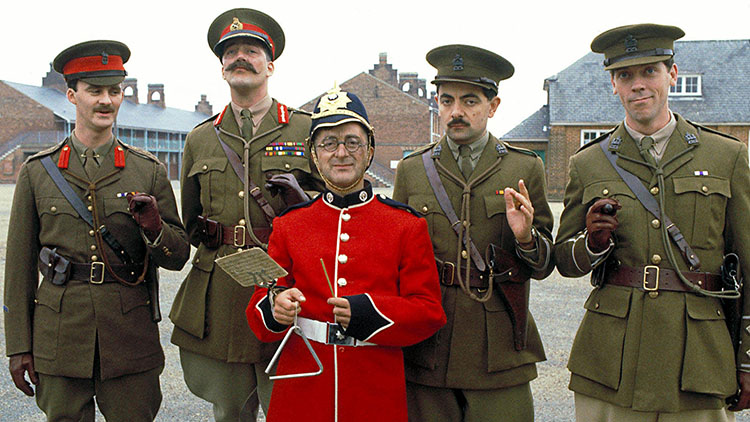

Most frequent words in each season of The Black Adder.

[figure not shown]

[The Black Adder Example Project](https://github.com/ALanguillaume/blackadder)

```r
html -------- text -------- words -------- figure -------> paper
```

## Summary

Code

==

Communication medium

1. **Enough vocabulary**: Learn enough else ask google
2. **Clear syntax**: Lay out ! Lay out ! Lay out !
3. **Clear structure**: Strive for modularity

## Thank you for your indulgence

## Bonus slides

## The Nested Loops Hydra

```r
workbooks <- sheets <- columns <- NULL
for (wb in workbooks) {
    for (s in sheets) {
        for (c in columns) {

            # Dante's inferno
            print("Abandon all hope, you who enter here...")

        }
    }
}
```

A clear sign something could be improved:

- Break down the problem into several functions
- You might not be using the adequate data structure to model your problem (lists are you friends)